# Rodriguez-Curcio-Final

TSA Effficency Data Sets

By Connor Rodriguez and Jaeden Curcio

https://crodriguez6.github.io/crodriguez6.github.io-final-project/

Imports:

```python
import pandas as pd
import numpy as np
import re
import matplotlib.pyplot as plt
import seaborn as sns
```

To export html:

```python
from google.colab import drive
drive.mount('/content/drive')
```

# Project Plan:

Jaedan and Connor have a regularly schedulded meeting time at 2pm every friday in Stanley Thomas Hall to work on our project. Additionally we are in close contact with each other and often study the subjects together on weekdays. We will likely use our usual study time to work on our project when our meeting is not sufficient for the workload or deadline. We communicate via cell phone and imessages, as well as github.

## **Project Goal:**

Our initial project goal was to analyse TSA data to see if the speed or efficency of TSA has changed over time by analyzing metrics such as total passengers traveling through TSA and speed in which TSA processes said passengers, in comparison with upgrades to TSA systems and global security events. Over time, however, our focus shifted to analyzing flight delay times, specifically Southwest airlines flights departing from MSY. Our current project goal is to create a regression model which aims to use historical data from these Southwest flights to predict future flight delay times.

# Table 1 - Airport Population by Day:

```python
data_link = "https://data.bts.gov/resource/hvq3-38u5.csv?$limit=500000"
df = pd.read_csv(data_link)
df
```

|  | mode | indicator | date | current | week_number | year |
| --- | --- | --- | --- | --- | --- | --- |
| 0 | Aviation | U.S. Domestic Commercial Flights (Departures) | 2019-01-01T00:00:00.000 | 21923 | 53 | 2019 |
| 1 | Aviation | U.S. Domestic Commercial Flights (Departures) | 2019-01-02T00:00:00.000 | 27113 | 53 | 2019 |
| 2 | Aviation | U.S. Domestic Commercial Flights (Departures) | 2019-01-03T00:00:00.000 | 26388 | 53 | 2019 |
| 3 | Aviation | U.S. Domestic Commercial Flights (Departures) | 2019-01-04T00:00:00.000 | 26043 | 53 | 2019 |
| 4 | Aviation | U.S. Domestic Commercial Flights (Departures) | 2019-01-05T00:00:00.000 | 21706 | 53 | 2019 |
| ... | ... | ... | ... | ... | ... | ... |
| 4110 | Aviation | Person Throughput at All Airports | 2022-10-22T00:00:00.000 | 1935404 | 43 | 2022 |
| 4111 | Aviation | Person Throughput at All Airports | 2022-10-23T00:00:00.000 | 2428428 | 44 | 2022 |
| 4112 | Aviation | Person Throughput at All Airports | 2022-10-24T00:00:00.000 | 2255851 | 44 | 2022 |
| 4113 | Aviation | Person Throughput at All Airports | 2022-10-25T00:00:00.000 | 1913820 | 44 | 2022 |
| 4114 | Aviation | Person Throughput at All Airports | 2022-10-26T00:00:00.000 | 1990205 | 44 | 2022 |

4115 rows × 6 columns

```python
df_total_people = df[df["indicator"] == "Person Throughput at All Airports"] #creates a new df containing only rows from the dataset with indicator value "Person Throughput at All Airports"
df_total_people["date"] = df_total_people["date"].str.slice(0, 10) #removes time section from date column
df_total_people.rename(columns={'current':"total_passengers"}, inplace = True) #renames "current" column to total_passengers for easier understanding
df_total_people.drop(columns=["mode"], inplace=True) #removes the redundant mode column
df_total_people.reset_index(drop=True, inplace=True) #resets the index
df_total_people
```

|  | indicator | date | total_passengers | week_number | year |
| --- | --- | --- | --- | --- | --- |
| 0 | Person Throughput at All Airports | 2019-01-01 | 2392125 | 1 | 2019 |
| 1 | Person Throughput at All Airports | 2019-01-02 | 2354510 | 1 | 2019 |
| 2 | Person Throughput at All Airports | 2019-01-03 | 2211239 | 1 | 2019 |
| 3 | Person Throughput at All Airports | 2019-01-04 | 2160942 | 1 | 2019 |
| 4 | Person Throughput at All Airports | 2019-01-05 | 1986061 | 1 | 2019 |
| ... | ... | ... | ... | ... | ... |
| 1390 | Person Throughput at All Airports | 2022-10-22 | 1935404 | 43 | 2022 |
| 1391 | Person Throughput at All Airports | 2022-10-23 | 2428428 | 44 | 2022 |
| 1392 | Person Throughput at All Airports | 2022-10-24 | 2255851 | 44 | 2022 |
| 1393 | Person Throughput at All Airports | 2022-10-25 | 1913820 | 44 | 2022 |
| 1394 | Person Throughput at All Airports | 2022-10-26 | 1990205 | 44 | 2022 |

1395 rows × 5 columns

We reformatted the data by removing unnecesarry data (the mode variable) and removing the time section from the date (each time was 0:00:00). We also renamed the "current" column to "total_passengers" for easier understanding. One other important change we made was to only return the data with indicator "person throughout all airports", in order to get the pure data for all flights, both US and international, and to avoid repeating date values.

Here's the mean.

```python
mean_passengers = df_total_people["total_passengers"].mean()
mean_passengers
```

```
np.float64(1657480.4630824372)
```

Here's the median

```python
median_passengers = df_total_people["total_passengers"].median()
median_passengers
```

```
1891205.0
```

Here's the standard deviation

```python
std_passengers = df_total_people["total_passengers"].std()
std_passengers
```

```
691368.9768962846
```

Here is the maximum, minimum, and range.

```python
max_passengers = df_total_people["total_passengers"].max()
print(max_passengers)
min_passengers = df_total_people["total_passengers"].min()
print(min_passengers)
print([min_passengers, max_passengers])
```

```
2809889
88341
[88341, 2809889]
```

Here's a line plot. There is a huge drop early on that is likley due to the pandemic

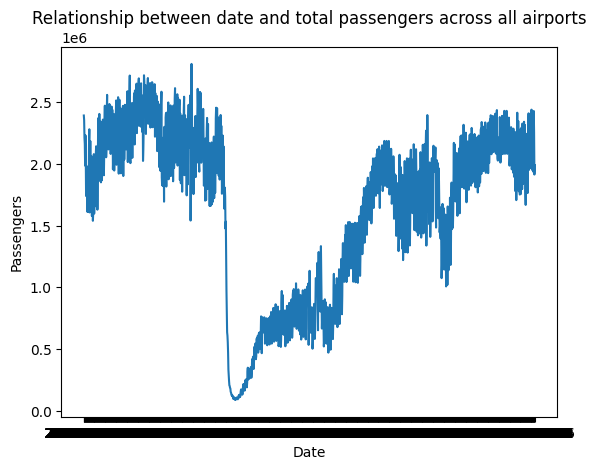

```python
plt.plot(df_total_people["date"], df_total_people["total_passengers"])
plt.title("Relationship between date and total passengers across all airports")
plt.xlabel("Date")
plt.ylabel("Passengers")
```

# Table 2 - US Domestic Flights:

```python
df_domestic = df[df["indicator"] == "U.S. Domestic Commercial Flights (Departures)"]
df_domestic["date"] = df_domestic["date"].str.slice(0, 10)
df_domestic.rename(columns={'current':"total_passengers"}, inplace = True)
df_domestic.drop(columns=["mode","indicator"], inplace=True)
df_domestic
```

|  | date | total_passengers | week_number | year |
| --- | --- | --- | --- | --- |
| 0 | 2019-01-01 | 21923 | 53 | 2019 |
| 1 | 2019-01-02 | 27113 | 53 | 2019 |
| 2 | 2019-01-03 | 26388 | 53 | 2019 |
| 3 | 2019-01-04 | 26043 | 53 | 2019 |
| 4 | 2019-01-05 | 21706 | 53 | 2019 |
| ... | ... | ... | ... | ... |
| 1355 | 2022-09-17 | 20327 | 38 | 2022 |
| 1356 | 2022-09-18 | 23377 | 39 | 2022 |
| 1357 | 2022-09-19 | 24159 | 39 | 2022 |
| 1358 | 2022-09-20 | 23552 | 39 | 2022 |
| 1359 | 2022-09-21 | 23148 | 39 | 2022 |

1360 rows × 4 columns

We are going to find the same metrics for the domestic data.

Here's the mean.

```python
mean_passengers = df_domestic["total_passengers"].mean()
mean_passengers
```

```
np.float64(21900.081617647058)
```

Here's the median.

```python
median_passengers = df_domestic["total_passengers"].median()
median_passengers
```

```
23448.0
```

Here is the Standard Deviation.

```python
std_passengers = df_domestic["total_passengers"].std()
std_passengers
```

```
5237.873229991935
```

And here is the maximum, minimum, and range.

```python
max_passengers = df_domestic["total_passengers"].max()
print(max_passengers)
min_passengers = df_domestic["total_passengers"].min()
print(min_passengers)
print([min_passengers, max_passengers])
```

```
29665
6679
[6679, 29665]
```

Now we are going to graph the same relationship for the domestic dataset.

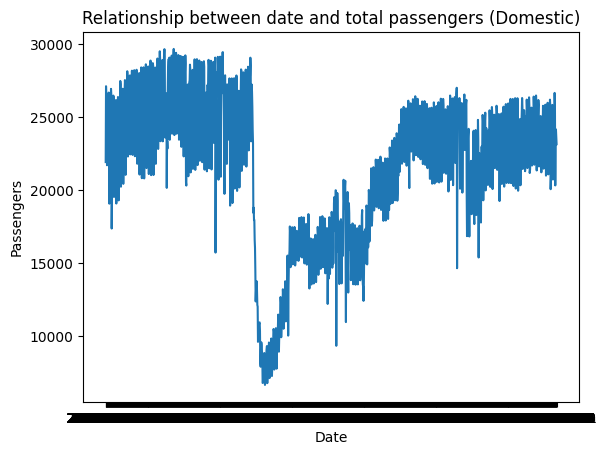

```python
plt.plot(df_domestic["date"], df_domestic["total_passengers"])
plt.title("Relationship between date and total passengers (Domestic)")
plt.xlabel("Date")
plt.ylabel("Passengers")
```

# Table 3 - US Commercial Flight Departures:

This is our other data set. This data set is similar to the previous two, but contains a differing range in dates, and contains record of a baseline and minimum. This data can help us answer other interesting questions such as how does season effect TSA rates and has the baseline amount of passengers increased overtime. It can be found here.

https://data.bts.gov/resource/bpqk-hyst

```python
data_link = "https://data.bts.gov/resource/bpqk-hyst.csv?$limit=500000"
df_2 = pd.read_csv(data_link)
```

```python
df_2["date"] = df_2["date"].str.slice(0, 10) #removing time section from date column
df_2.rename(columns={'current':"total_passengers"}, inplace = True) #renaming current column to total_passengers (in place as to not return a copy)
df_2["week_num"] = df_2["week_num"].astype(int) #week_num had some interesting decimals that didn't quite make much sense, so converted type to streamline data
df_2
```

|  | mode | indicator | date | week_num | lowest | total_passengers | baseline |
| --- | --- | --- | --- | --- | --- | --- | --- |
| 0 | Aviation | U.S. Domestic Commercial Flights (Departures) | 2021-08-01 | 32 | 6679.0 | 23553 | 26791 |
| 1 | Aviation | U.S. Domestic Commercial Flights (Departures) | 2021-08-02 | 32 | 6679.0 | 23840 | 28337 |
| 2 | Aviation | U.S. Domestic Commercial Flights (Departures) | 2021-08-03 | 32 | 6679.0 | 23705 | 28660 |
| 3 | Aviation | U.S. Domestic Commercial Flights (Departures) | 2021-08-04 | 32 | 6679.0 | 24411 | 27821 |
| 4 | Aviation | U.S. Domestic Commercial Flights (Departures) | 2021-08-05 | 32 | 6679.0 | 25241 | 29244 |
| ... | ... | ... | ... | ... | ... | ... | ... |
| 2436 | Aviation | U.S. International Commercial Flights (Departu... | 2021-03-23 | 13 | 326.0 | 1679 | 4150 |
| 2437 | Aviation | U.S. International Commercial Flights (Departu... | 2021-03-24 | 13 | 326.0 | 1824 | 4347 |
| 2438 | Aviation | U.S. International Commercial Flights (Departu... | 2021-03-25 | 13 | 326.0 | 1895 | 4448 |
| 2439 | Aviation | U.S. International Commercial Flights (Departu... | 2021-03-26 | 13 | 326.0 | 1970 | 4517 |
| 2440 | Aviation | U.S. International Commercial Flights (Departu... | 2021-03-27 | 13 | 326.0 | 2250 | 4900 |

2441 rows × 7 columns

These are more metrics for the second data set, such as mean, median, and Standard Deviation.

```python
mean_passengers = df_2["total_passengers"].mean()
mean_passengers
```

```
np.float64(424902.4055714871)
```

```python
median_passengers = df_2["total_passengers"].median()
median_passengers
```

```
20076.0
```

```python
std_passengers = df_2["total_passengers"].std()
std_passengers
```

```
692497.7748464367
```

```python
max_passengers = df_2["total_passengers"].max()
print(max_passengers)
min_passengers = df_2["total_passengers"].min()
print(min_passengers)
print([min_passengers, max_passengers])
```

```
2455408
326
[326, 2455408]
```

Alright cool. So now we have all this data with corresponding dates about TSA, but we still don't have the wait times. There is good news and bad news. Good news, the data exists. Bad news, it's completely out of date.

# Table 4 - MSY Southwest Airline Departures:

This is our final, and most important dataset. This dataset lists every Southwest Airline flight departing from MSY Airport between the years 2005 and 2025, alongside flight numbers, destination airport, and the flight's delay times. We will use this dataset, alongside the others, to train a regression model that can ideally predict the estimated delay time of any Southwest flight from MSY, given destination airport, time of day, date, and total airport passengers from that day.

```python
df_detailed_stats = pd.read_csv('/content/drive/MyDrive/Detailed_Statistics_Departures.csv', header=[6])
display(df_detailed_stats.head())
```

|  | Carrier Code | Date (MM/DD/YYYY) | Flight Number | Tail Number | Destination Airport | Scheduled departure time | Actual departure time | Departure delay (Minutes) |
| --- | --- | --- | --- | --- | --- | --- | --- | --- |
| 0 | WN | 01/01/2005 | 20.0 | N502 | HOU | 09:30 | 09:30 | 0.0 |
| 1 | WN | 01/01/2005 | 106.0 | N632SW | HOU | 19:50 | 19:50 | 0.0 |
| 2 | WN | 01/01/2005 | 109.0 | N314SW | TPA | 14:20 | 14:25 | 5.0 |
| 3 | WN | 01/01/2005 | 121.0 | N405 | LAS | 08:05 | 08:18 | 13.0 |
| 4 | WN | 01/01/2005 | 167.0 | N512 | DAL | 13:30 | 13:30 | 0.0 |

```python
display(df_detailed_stats.head())
display(df_domestic.head())
```

|  | Carrier Code | Date (MM/DD/YYYY) | Flight Number | Tail Number | Destination Airport | Scheduled departure time | Actual departure time | Departure delay (Minutes) |
| --- | --- | --- | --- | --- | --- | --- | --- | --- |
| 0 | WN | 01/01/2005 | 20.0 | N502 | HOU | 09:30 | 09:30 | 0.0 |
| 1 | WN | 01/01/2005 | 106.0 | N632SW | HOU | 19:50 | 19:50 | 0.0 |
| 2 | WN | 01/01/2005 | 109.0 | N314SW | TPA | 14:20 | 14:25 | 5.0 |
| 3 | WN | 01/01/2005 | 121.0 | N405 | LAS | 08:05 | 08:18 | 13.0 |
| 4 | WN | 01/01/2005 | 167.0 | N512 | DAL | 13:30 | 13:30 | 0.0 |

|  | date | total_passengers | week_number | year |
| --- | --- | --- | --- | --- |
| 0 | 2019-01-01 | 21923 | 53 | 2019 |
| 1 | 2019-01-02 | 27113 | 53 | 2019 |
| 2 | 2019-01-03 | 26388 | 53 | 2019 |
| 3 | 2019-01-04 | 26043 | 53 | 2019 |
| 4 | 2019-01-05 | 21706 | 53 | 2019 |

```python
#Convert Dates to date time
df_detailed_stats['Date'] = pd.to_datetime(df_detailed_stats['Date (MM/DD/YYYY)'], format='%m/%d/%Y')
df_domestic['date'] = pd.to_datetime(df_domestic['date'])

#Merge
merged_df = pd.merge(df_detailed_stats, df_domestic, left_on='Date', right_on='date', how='inner')

merged_df.head()
```

|  | Carrier Code | Date (MM/DD/YYYY) | Flight Number | Tail Number | Destination Airport | Scheduled departure time | Actual departure time | Departure delay (Minutes) | Date | date | total_passengers | week_number | year |
| --- | --- | --- | --- | --- | --- | --- | --- | --- | --- | --- | --- | --- | --- |
| 0 | WN | 01/01/2019 | 9.0 | N922WN | DAL | 06:40 | 06:49 | 9.0 | 2019-01-01 | 2019-01-01 | 21923 | 53 | 2019 |
| 1 | WN | 01/01/2019 | 167.0 | N928WN | AUS | 07:20 | 07:19 | -1.0 | 2019-01-01 | 2019-01-01 | 21923 | 53 | 2019 |
| 2 | WN | 01/01/2019 | 175.0 | N7838A | BNA | 07:45 | 07:50 | 5.0 | 2019-01-01 | 2019-01-01 | 21923 | 53 | 2019 |
| 3 | WN | 01/01/2019 | 205.0 | N8716B | DAL | 14:20 | 14:19 | -1.0 | 2019-01-01 | 2019-01-01 | 21923 | 53 | 2019 |
| 4 | WN | 01/01/2019 | 281.0 | N7829B | HOU | 18:35 | 18:37 | 2.0 | 2019-01-01 | 2019-01-01 | 21923 | 53 | 2019 |

```python
# Drop rows where the target variable 'Departure delay (Minutes)' is NaN
model_df = merged_df.dropna(subset=['Departure delay (Minutes)']).copy()
```

```python
model_df['month'] = model_df['Date'].dt.month
model_df['day'] = model_df['Date'].dt.day
model_df.drop(columns=["date"], inplace=True)

model_df.head()
```

|  | Carrier Code | Date (MM/DD/YYYY) | Flight Number | Tail Number | Destination Airport | Scheduled departure time | Actual departure time | Departure delay (Minutes) | Date | total_passengers | week_number | year | month | day |
| --- | --- | --- | --- | --- | --- | --- | --- | --- | --- | --- | --- | --- | --- | --- |
| 0 | WN | 01/01/2019 | 9.0 | N922WN | DAL | 06:40 | 06:49 | 9.0 | 2019-01-01 | 21923 | 53 | 2019 | 1 | 1 |
| 1 | WN | 01/01/2019 | 167.0 | N928WN | AUS | 07:20 | 07:19 | -1.0 | 2019-01-01 | 21923 | 53 | 2019 | 1 | 1 |
| 2 | WN | 01/01/2019 | 175.0 | N7838A | BNA | 07:45 | 07:50 | 5.0 | 2019-01-01 | 21923 | 53 | 2019 | 1 | 1 |
| 3 | WN | 01/01/2019 | 205.0 | N8716B | DAL | 14:20 | 14:19 | -1.0 | 2019-01-01 | 21923 | 53 | 2019 | 1 | 1 |
| 4 | WN | 01/01/2019 | 281.0 | N7829B | HOU | 18:35 | 18:37 | 2.0 | 2019-01-01 | 21923 | 53 | 2019 | 1 | 1 |

Here's the mean and median departure delay time, as well as the max and min.

```python
model_df["Departure delay (Minutes)"].mean()
```

```
np.float64(10.429504069816229)
```

```python
model_df["Departure delay (Minutes)"].median()
```

```
0.0
```

```python
max_delay = model_df["Departure delay (Minutes)"].max()
min_delay = model_df["Departure delay (Minutes)"].min()
print(min_delay)
print(max_delay)
```

```
-21.0
561.0
```

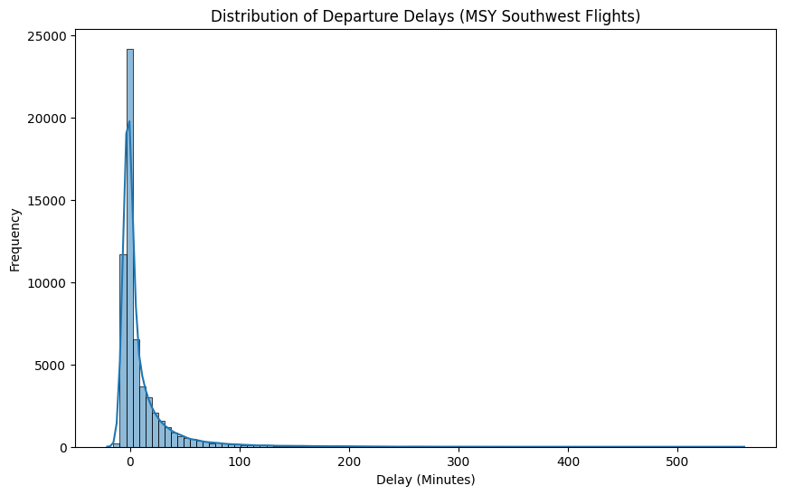

```python
 plt.figure(figsize=(10,6))

sns.histplot(model_df["Departure delay (Minutes)"], bins=100, kde=True)

plt.title("Distribution of Departure Delays (MSY Southwest Flights)")
plt.xlabel("Delay (Minutes)")
plt.ylabel("Frequency")

plt.show()
```

This table is a frequency distribution of each flight's delay time. We can see that the distribution has a large right skew, including some extremely high delay times (over 500 minutes), while a majority of the flight delays are centered around 0.

```python
dest_airport_counts = model_df['Destination Airport'].value_counts()
dest_airport_counts
```

| Destination Airport | count |
| --- | --- |
| HOU | 7996 |
| DAL | 7479 |
| MCO | 4229 |
| BNA | 3833 |
| ATL | 3793 |
| MDW | 3720 |
| BWI | 3174 |
| DEN | 3105 |
| AUS | 2897 |
| TPA | 2828 |
| FLL | 2293 |
| DCA | 1780 |
| STL | 1771 |
| LAS | 1733 |
| IAH | 1577 |
| LAX | 1437 |
| PHX | 1399 |
| SAT | 1001 |
| LGA | 882 |
| MCI | 823 |
| SAN | 598 |
| OAK | 596 |
| MIA | 387 |
| RDU | 80 |
| IND | 57 |
| CMH | 46 |
| PIT | 28 |
| SJC | 24 |
| SMF | 14 |
| OKC | 5 |

**dtype:** int64

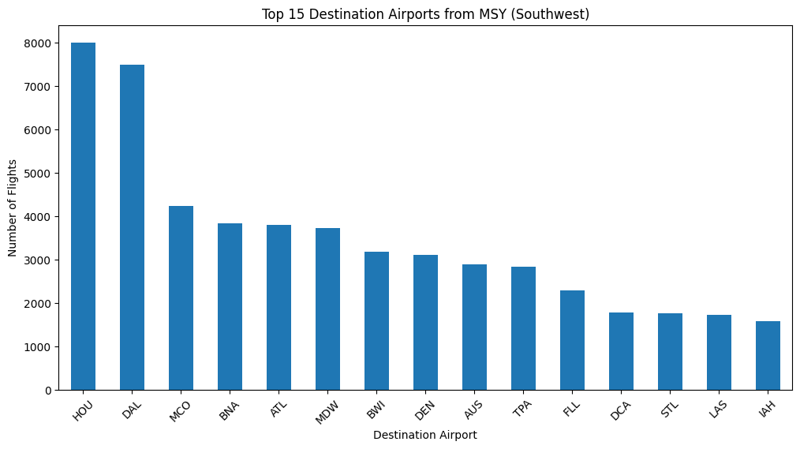

```python
top_airports = dest_airport_counts.head(15)

plt.figure(figsize=(12,6))
top_airports.plot(kind='bar')

plt.title("Top 15 Destination Airports from MSY (Southwest)")
plt.xlabel("Destination Airport")
plt.ylabel("Number of Flights")

plt.xticks(rotation=45)
plt.show()
```

This graph is a visualization of the top 15 destination airports based on number of flights from MSY. We can see that the top two by a large margin are Houston and Dallas, and a majority of the airports with the highest number of flights are larger nearby airports such as texas airports, Atlanta, and Nashville.

```python
avg_delays = model_df.groupby('Destination Airport')['Departure delay (Minutes)'].mean()

avg_delays.drop(["RDU", "IND", "CMH", "PIT", "SJC", "SMF", "OKC"], inplace=True)
avg_delays.sort_values(ascending=False, inplace=True)
```

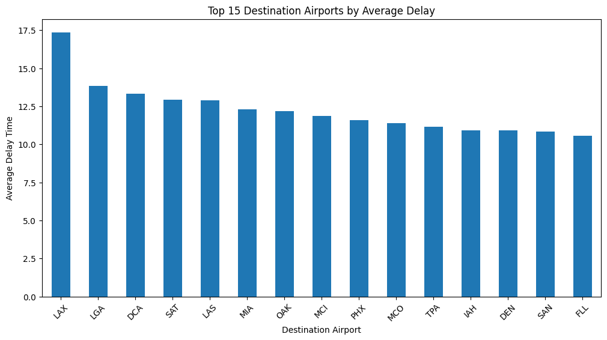

```python
highest_avg_delays = avg_delays.head(15)
plt.figure(figsize=(12,6))
highest_avg_delays.plot(kind='bar')

plt.title("Top 15 Destination Airports by Average Delay")
plt.xlabel("Destination Airport")
plt.ylabel("Average Delay Time")

plt.xticks(rotation=45)
plt.show()
```

```python
avg_delays
```

| Destination Airport | Departure delay (Minutes) |
| --- | --- |
| LAX | 17.360473 |
| LGA | 13.852608 |
| DCA | 13.331461 |
| SAT | 12.915085 |
| LAS | 12.892672 |
| MIA | 12.286822 |
| OAK | 12.199664 |
| MCI | 11.851762 |
| PHX | 11.603288 |
| MCO | 11.392764 |
| TPA | 11.156648 |
| IAH | 10.929613 |
| DEN | 10.911111 |
| SAN | 10.829431 |
| FLL | 10.547754 |
| DAL | 10.299372 |
| HOU | 10.030640 |
| AUS | 9.688989 |
| BWI | 8.761500 |
| MDW | 8.481452 |
| STL | 8.444946 |
| BNA | 8.331594 |
| ATL | 8.325863 |

**dtype:** float64

This graph is a visualization of the top 15 destination airports with the highest average delay time on Southwest flights departing from MSY airport. We can see that the airport with highest average delay time is (unsurprisingly) LAX.

# Models

Using this data, we plan to build two models. The first model will be a linear regression model which aims to predict the total airport population of a day, and the second model will use that predicted value alongside destination airport, time of day, and date to predict the delay time of future Southwest airlines flights.

```python
X = model_df[["Destination Airport", "total_passengers", "Scheduled departure time", "month", "day"]]
y = model_df["Departure delay (Minutes)"]
```

```python
from sklearn.model_selection import train_test_split

#We then use the splitting function to split the test data and training data with testing being 20% of the data
X_train, X_test, y_train, y_test = train_test_split(X, y, test_size=0.2, random_state=0)
```

```python
from sklearn import svm
from sklearn.compose import ColumnTransformer
from sklearn.preprocessing import OneHotEncoder, FunctionTransformer
import pandas as pd
import numpy as np

#This function converts time to minutes froim midnight
def time_to_minutes_transformer(X):
    if X.empty:
        return np.array([]).reshape(0, 1)
    return X.iloc[:, 0].apply(lambda t: pd.to_datetime(t, format='%H:%M').hour * 60 + pd.to_datetime(t, format='%H:%M').minute).values.reshape(-1, 1)

#Split data up by type
categorical_features = ['Destination Airport']
time_features = ['Scheduled departure time']
numerical_features = ['total_passengers', 'month', 'day']

#Preprocessor
preprocessor = ColumnTransformer(
    transformers=[
        ('cat', OneHotEncoder(handle_unknown='ignore'), categorical_features),
        ('time', FunctionTransformer(time_to_minutes_transformer, validate=False), time_features),
        ('num', 'passthrough', numerical_features)
    ],
    remainder='drop'
)
```

```python
#Apply preprocessing
X_train_processed = preprocessor.fit_transform(X_train)
X_test_processed = preprocessor.transform(X_test)
```

```python
from sklearn.linear_model import LinearRegression

#Train
clf = LinearRegression()
clf.fit(X_train_processed, y_train)

#Evaluate
clf.score(X_test_processed, y_test)
```

```
0.05166319530109997
```

```python
df_domestic.columns
```

```
Index(['date', 'total_passengers', 'week_number', 'year'], dtype='object')
```

```python
df_domestic['month'] = df_domestic['date'].dt.month
df_domestic['day'] = df_domestic['date'].dt.day

display(df_domestic.head())
```

|  | date | total_passengers | week_number | year | month | day |
| --- | --- | --- | --- | --- | --- | --- |
| 0 | 2019-01-01 | 21923 | 53 | 2019 | 1 | 1 |
| 1 | 2019-01-02 | 27113 | 53 | 2019 | 1 | 2 |
| 2 | 2019-01-03 | 26388 | 53 | 2019 | 1 | 3 |
| 3 | 2019-01-04 | 26043 | 53 | 2019 | 1 | 4 |
| 4 | 2019-01-05 | 21706 | 53 | 2019 | 1 | 5 |

```python
X = df_domestic[["month", "day"]]
y = df_domestic["total_passengers"]
```

```python
X_train, X_test, y_train, y_test = train_test_split(X, y, test_size=0.2, random_state=0)
```

```python
from sklearn.linear_model import LinearRegression
people_predictor = LinearRegression()
people_predictor.fit(X_train, y_train)

people_predictor.score(X_test, y_test)
```

```
0.004810806544176871
```

```python
#New data
new_data_input = pd.DataFrame({
    'Destination Airport': ['STL', 'LAX'],
    'Scheduled departure time': ['5:00', '18:00'],
    'month': [6, 10],
    'day': [20, 20]
})

#Predict total_passengers
predicted_passengers = people_predictor.predict(new_data_input[['month', 'day']])

#Add predicted_passengers to new data frame
new_data = new_data_input.copy()
new_data['total_passengers'] = predicted_passengers

#Preprocess
new_data_processed = preprocessor.transform(new_data)

#Predictions
predictions = clf.predict(new_data_processed)

print("Predictions for new data:")
print(predictions)
```

```
Predictions for new data:
[-0.06537641 18.07411937]
```

```python
!jupyter nbconvert /content/drive/MyDrive/Colab Notebooks/Rodriguez-Curcio-Final.ipynb --to html
```

[output not shown]

[output cut: 137 more lines]

[output not shown]